# glmhmm metacognition

## ———————————————————————

## LIBRARIES AND FUNCTIONS

```r
library(reticulate)
use_condaenv("glmhmm")

source_python("python/glm_hmm.py")
```

```python
reticulate::repl_python()
import numpy as np
import numpy.random as npr
import matplotlib.pyplot as plt
import ssm
```

```r
quit
library(tidyverse)
library(broom)
library(dplyr)
library(R.matlab)
library(cowplot)

list.files("R", full.names = TRUE) |>
  walk(source)
```

| Download of data (Buno) |
| --- |

In experiment 2, a calibration procedure was added to maintain a constant level of performance both during the experiment and across participants

- stimulus refers to which group of dots (right or left) has more of them (check; the quantity of trials with more dots either on the left or right group varies from subject to subject).
- dot_diff is the difference of dots between stimuli (subject where asked which stimulus had more dots).
- confidence is the confidence scale meassured with a 11-point probabilistic rating scale (1=certainly wrong, 3=probably wrong, 5=maybe wrong, 7=maybe correct, 9=probably correct, 11=certainly correct)

| subject | stimulus | response | confidence | RT | dot_diff | correct | trial |
| --- | --- | --- | --- | --- | --- | --- | --- |
| 1 | 1 | 0 | 7 | 0.906 | 43 | 0 | 1 |
| 1 | 1 | 0 | 9 | 0.626 | 15 | 0 | 2 |
| 1 | 1 | 1 | 5 | 1.253 | 13 | 1 | 3 |
| 1 | 1 | 1 | 8 | 0.634 | 2 | 1 | 4 |
| 1 | 1 | 1 | 7 | 0.731 | 49 | 1 | 5 |
| 1 | 1 | 1 | 8 | 0.567 | 52 | 1 | 6 |
| 1 | -1 | 0 | 7 | 2.487 | -33 | 1 | 7 |
| 1 | -1 | 1 | 7 | 0.744 | -4 | 0 | 8 |
| 1 | -1 | 1 | 8 | 0.504 | -58 | 0 | 9 |
| 1 | 1 | 1 | 8 | 0.557 | 21 | 1 | 10 |

[output cut: 990 more lines]

| General analysis |
| --- |

Proportions of left (-1) and right (1) stimuli

```r
data_trials |>
  group_by(subject) |>
  count(stimulus) |>
  group_by(subject) |>
  mutate(prop = n / sum(n)) |>
  select(-n) |>
  pivot_wider(names_from = stimulus, values_from = prop)
```

| subject | -1 | 1 |
| --- | --- | --- |
| 1 | 0.5476190 | 0.4523810 |
| 2 | 0.5476190 | 0.4523810 |
| 3 | 0.4761905 | 0.5238095 |
| 4 | 0.4523810 | 0.5476190 |
| 5 | 0.5238095 | 0.4761905 |
| 6 | 0.4523810 | 0.5476190 |
| 7 | 0.4761905 | 0.5238095 |
| 8 | 0.5238095 | 0.4761905 |
| 9 | 0.5000000 | 0.5000000 |
| 10 | 0.5238095 | 0.4761905 |

[output cut: 488 more lines]

## ———————————————————————

## 2S GENERAL

| s01 2S |
| --- |

S01

```r
data_trials_s01 <- data_trials %>%
  filter(subject == 1)
```

```r
s01_design_matrix <- data_trials_s01 %>%
  mutate(session = 1,
         intercept = 1,
         dot_diff = dot_diff) %>%
  ungroup() %>%
  select(session, response, intercept, dot_diff)

s01_design_matrix
```

| session | response | intercept | dot_diff |
| --- | --- | --- | --- |
| 1 | 0 | 1 | 43 |
| 1 | 0 | 1 | 15 |
| 1 | 1 | 1 | 13 |
| 1 | 1 | 1 | 2 |
| 1 | 1 | 1 | 49 |
| 1 | 1 | 1 | 52 |
| 1 | 0 | 1 | -33 |
| 1 | 1 | 1 | -4 |
| 1 | 1 | 1 | -58 |
| 1 | 1 | 1 | 21 |

[output cut: 200 more lines]

S02

```r
s02_design_matrix <- data_trials %>%
  filter(subject == 2) %>%
  mutate(session = 1,
         intercept = 1,
         dot_diff = dot_diff) %>%
  ungroup() %>%
  select(session, response, intercept, dot_diff)

s02_design_matrix
```

| session | response | intercept | dot_diff |
| --- | --- | --- | --- |
| 1 | 1 | 1 | 51 |
| 1 | 1 | 1 | -25 |
| 1 | 1 | 1 | 30 |
| 1 | 0 | 1 | -10 |
| 1 | 1 | 1 | 31 |
| 1 | 1 | 1 | -15 |
| 1 | 0 | 1 | -1 |
| 1 | 0 | 1 | -16 |
| 1 | 0 | 1 | -54 |
| 1 | 1 | 1 | -4 |

[output cut: 200 more lines]

```r
glm_hmm2_seeds_s01 <- s01_design_matrix %>%
  glm_hmm_r(.num_states = 2, .seeds = 1:40, .all_seeds = TRUE)

glm_hmm2_seeds_s01
```

| seed | log_lik | n_par | fit |
| --- | --- | --- | --- |
| 1 | -106.9679 | 6 |  |
| 2 | -107.7606 | 6 |  |
| 3 | -107.7606 | 6 |  |
| 4 | -107.7606 | 6 |  |
| 5 | -107.7606 | 6 |  |
| 6 | -107.7606 | 6 |  |
| 7 | -107.7606 | 6 |  |
| 8 | -107.7606 | 6 |  |
| 9 | -107.7606 | 6 |  |
| 10 | -107.7606 | 6 |  |

[output cut: 30 more lines]

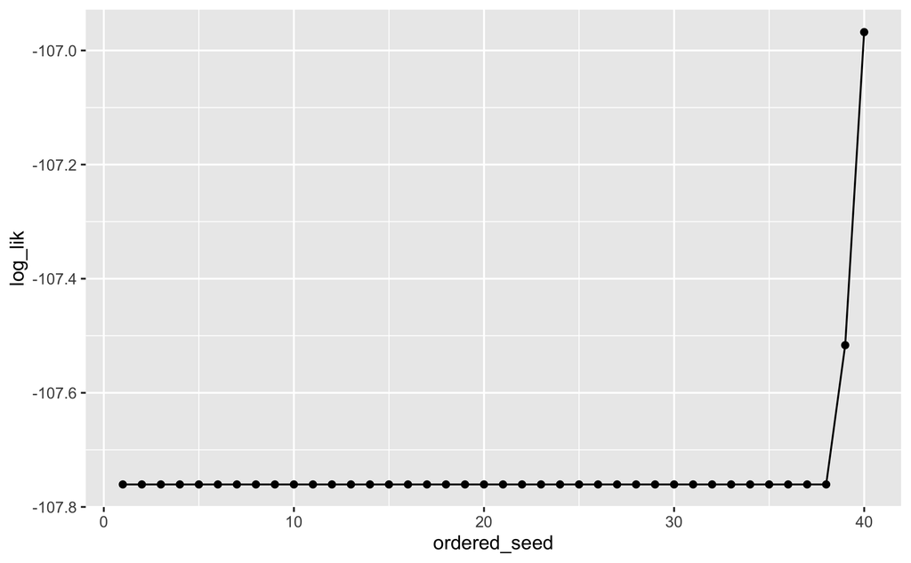

```r
glm_hmm2_seeds_s01 %>%
  arrange(log_lik) %>%
  mutate(ordered_seed = row_number()) %>%
  ggplot(aes(ordered_seed, log_lik)) +
  geom_line() +
  geom_point()
```

```r
glm_hmm2_s01 <- glm_hmm2_seeds_s01 |>
   filter(log_lik == max(log_lik)) |>
   pluck("fit") %>%
   pluck(1)

glm_hmm2_s01
```

| session | response | intercept | dot_diff |
| --- | --- | --- | --- |
| 1 | 0 | 1 | 43 |
| 1 | 0 | 1 | 15 |
| 1 | 1 | 1 | 13 |
| 1 | 1 | 1 | 2 |
| 1 | 1 | 1 | 49 |
| 1 | 1 | 1 | 52 |
| 1 | 0 | 1 | -33 |
| 1 | 1 | 1 | -4 |
| 1 | 1 | 1 | -58 |
| 1 | 1 | 1 | 21 |

[output cut: 200 more lines]

```
$log_prob
[1] -138.2757

$log_prior
[1] -31.30783

$log_lik
[1] -106.9679

$n_par
[1] 6

$recovered_weights
```

| state | coef | value |
| --- | --- | --- |
| S1 | V1 | 45.85556890 |
| S1 | V2 | -3.30366286 |
| S2 | V1 | 1.16990335 |
| S2 | V2 | 0.02888067 |

```
$transitions_tengo_que_reordenar_segun_estados_ordenados
            [,1]          [,2]
[1,]  -0.4826015 -9.601791e-01
[2,] -14.9964688 -3.069845e-07

$posterior_probs
```

| session | trial | state | p |
| --- | --- | --- | --- |
| 1 | 1 | S1 | 1.000000e+00 |
| 1 | 1 | S2 | 2.396406e-10 |
| 1 | 2 | S1 | 8.911112e-01 |
| 1 | 2 | S2 | 1.088888e-01 |
| 1 | 3 | S1 | 4.996919e-01 |
| 1 | 3 | S2 | 5.003081e-01 |
| 1 | 4 | S1 | 2.217756e-01 |
| 1 | 4 | S2 | 7.782244e-01 |
| 1 | 5 | S1 | 6.016520e-52 |
| 1 | 5 | S2 | 1.000000e+00 |

[output cut: 410 more lines]

```
NA
```

```r
psycho2_s01 <- glm_hmm2_s01$recovered_weights |>
  group_by(state) |>
  reframe(create_psychometric(dot_diff, value))
```

```r
posterior_wins2_s01 <- glm_hmm2_s01$posterior_probs |>
    group_by(trial) %>%
    filter(p == max(p)) %>%
    select(-p)

posterior_wins2_s01 |> ungroup() |> count(state)
```

| state | n |
| --- | --- |
| S1 | 2 |
| S2 | 208 |

```r
averages_states2_s01 <- glm_hmm2_s01$model_matrix_with_session %>%
    mutate(trial = row_number()) %>%
    left_join(posterior_wins2_s01, by = c("session", "trial")) %>%
    mutate(dot_diff_bin = cut_interval(dot_diff, 10)) |>
    group_by(dot_diff_bin, state) %>%
    summarise(dot_diff = mean(dot_diff),
              prob = mean(response),
              n = n(),
              .groups = "keep")
```

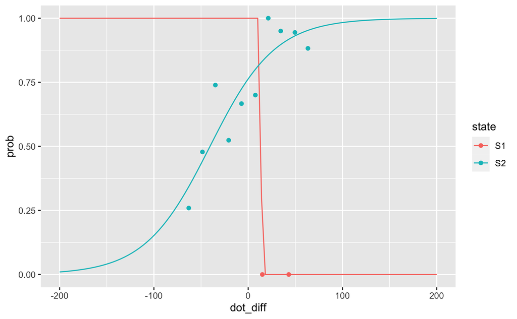

```r
ggplot() +
  geom_point(data = averages_states2_s01,
             aes(dot_diff, prob, color = state)) +
  geom_line(data = psycho2_s01,
            aes(x = dot_diff, y = prop, color = state))
```

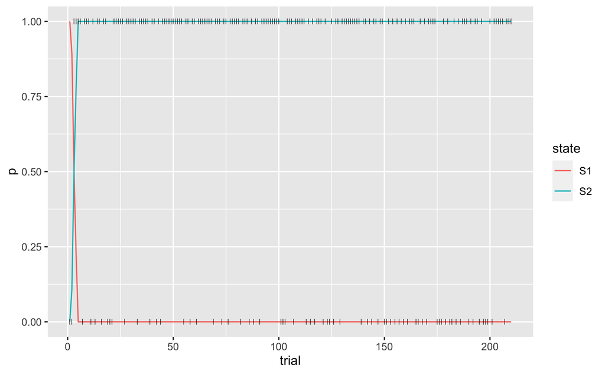

```r
s01_2_trials_plot <- ggplot() +
  geom_line(data = glm_hmm2_s01$posterior_probs,
            aes(x = trial, y = p, color = state)) +
  geom_point(data = data_trials_s01,
             aes(x = trial, y = response), shape = "|")

s01_2_trials_plot
```

```r
posterior_wins2_s01 |>
  ungroup() |>
  count(state)
```

| state | n |
| --- | --- |
| S1 | 2 |
| S2 | 208 |

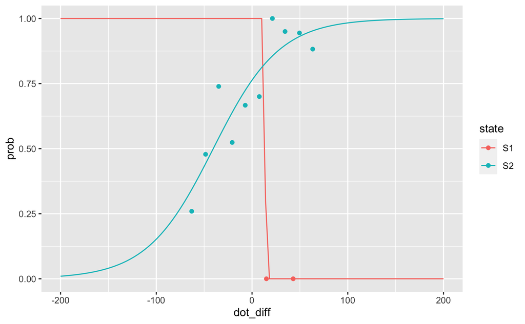

```r
plotting_psycho_one_participant(glm_hmm2_s01)
```

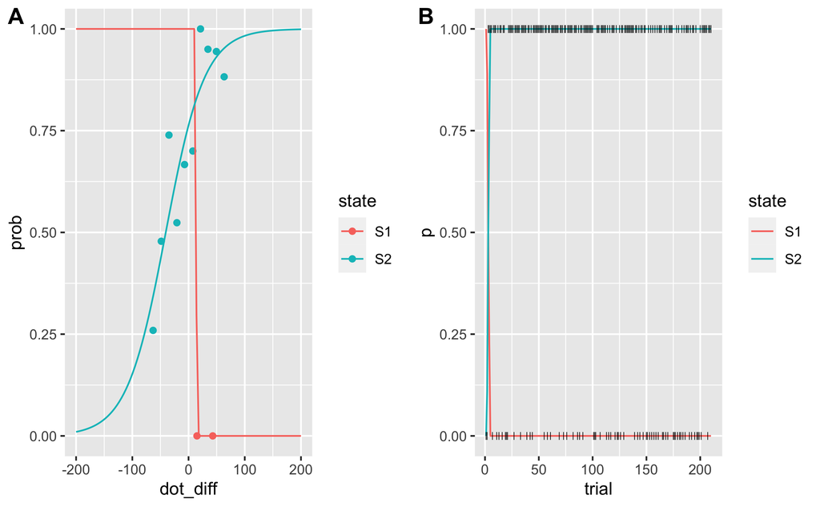

```r
plot_grid(plotting_psycho_one_participant(glm_hmm2_s01),
          plotting_trials_one_participant(glm_hmm2_s01),
          rel_widths = c(.5, .5),
          labels = "AUTO")
```

| All 2S |
| --- |

```r
design_matrix_all <- data_trials %>%
  mutate(session = 1,
         intercept = 1,
         dot_diff = dot_diff) %>%
  ungroup() %>%
  select(subject, session, response, intercept, dot_diff) |>
  filter(subject <= 50) # solo 10 participantes

design_matrix_all
```

| subject | session | response | intercept | dot_diff |
| --- | --- | --- | --- | --- |
| 1 | 1 | 0 | 1 | 43 |
| 1 | 1 | 0 | 1 | 15 |
| 1 | 1 | 1 | 1 | 13 |
| 1 | 1 | 1 | 1 | 2 |
| 1 | 1 | 1 | 1 | 49 |
| 1 | 1 | 1 | 1 | 52 |
| 1 | 1 | 0 | 1 | -33 |
| 1 | 1 | 1 | 1 | -4 |
| 1 | 1 | 1 | 1 | -58 |
| 1 | 1 | 1 | 1 | 21 |

[output cut: 990 more lines]

Esto tarda mucho porque hace muchos ajustes:

```r
glm_hmm2_all_seeds <- design_matrix_all |>
  group_by(subject) |>
  nest() %>%
  rowwise() %>%
  mutate(fit = list(glm_hmm_r(data,
                              .num_states = 2, .seeds = 1:20,
                              .all_seeds = TRUE)))
```

```r
glm_hmm2_all <- glm_hmm2_all_seeds %>%
  mutate(fit = list(glm_hmm_extract_best(fit)))
```

```r
#save(glm_hmm_2_all, file = "RData/glm_hmm_all_seeds_2.RData")
```

```r
#load("RData/glm_hmm_all_seeds_2.RData")
```

MÉTODO PARA ORDENAR ESTADOS SEGUN ALGUNA VARIABLE

| subject | state | coef | value |
| --- | --- | --- | --- |
| 1 | S1 | V1 | 1.169903e+00 |
| 1 | S1 | V2 | 2.888067e-02 |
| 1 | S2 | V1 | 4.585557e+01 |
| 1 | S2 | V2 | -3.303663e+00 |
| 2 | S1 | V1 | 9.947843e-01 |
| 2 | S1 | V2 | 4.392166e-02 |
| 2 | S2 | V1 | 7.765317e-01 |
| 2 | S2 | V2 | 4.250141e-02 |
| 3 | S1 | V1 | -3.271376e-01 |
| 3 | S1 | V2 | 5.504725e-02 |

[output cut: 190 more lines]

```r
liks_glm_hmm2_all <- glm_hmm2_all %>%
  unnest_wider(fit) %>%
  mutate(n = map(data, count)) %>%
  unnest(n) %>%
  select(subject, log_lik, n_par, n) %>%
  mutate(model = "int-slo 2")
```

plotting

```r
plots_2_all <- glm_hmm2_all %>%
    rowwise() %>%
    mutate(p = list(plotting_one_participant(fit, subject)))

plots_2_all_grid <- plot_grid(plotlist = plots_2_all$p, ncol = 2)

file_name <- paste0("figures/", deparse(substitute(.glm_hmm)), ".pdf")

ggsave("figures/plots_2_grid.pdf",
       plots_2_all_grid, width = 10, height = 10)
```

## ———————————————————————

## 3S GENERAL

| s01 3S |
| --- |

```r
glm_hmm3_s01 <- s01_design_matrix %>%
  glm_hmm_r(.num_states = 3)

glm_hmm3_s01
```

| session | response | intercept | dot_diff |
| --- | --- | --- | --- |
| 1 | 0 | 1 | 43 |
| 1 | 0 | 1 | 15 |
| 1 | 1 | 1 | 13 |
| 1 | 1 | 1 | 2 |
| 1 | 1 | 1 | 49 |
| 1 | 1 | 1 | 52 |
| 1 | 0 | 1 | -33 |
| 1 | 1 | 1 | -4 |
| 1 | 1 | 1 | -58 |
| 1 | 1 | 1 | 21 |

[output cut: 200 more lines]

```
$log_prob
[1] -151.7385

$log_prior
[1] -46.96019

$log_lik
[1] -104.7783

$n_par
[1] 12

$recovered_weights
```

| state | coef | value |
| --- | --- | --- |
| S1 | V1 | 1.33547917 |
| S1 | V2 | 0.02321393 |
| S2 | V1 | 0.85989634 |
| S2 | V2 | 0.05752535 |
| S3 | V1 | -7.77508987 |
| S3 | V2 | -0.03505633 |

```
$transitions_tengo_que_reordenar_segun_estados_ordenados
           [,1]          [,2]         [,3]
[1,]  -1.020164  -0.447124818 -49.62065982
[2,] -11.383481  -0.007751797  -4.86517910
[3,]  -3.720230 -10.905186047  -0.02454555

$posterior_probs
```

| session | trial | state | p |
| --- | --- | --- | --- |
| 1 | 1 | S3 | 1.000000e+00 |
| 1 | 1 | S1 | 4.316100e-10 |
| 1 | 1 | S2 | 3.402308e-11 |
| 1 | 2 | S3 | 6.985814e-01 |
| 1 | 2 | S1 | 3.014186e-01 |
| 1 | 2 | S2 | 1.817066e-11 |
| 1 | 3 | S3 | 8.065496e-05 |
| 1 | 3 | S1 | 9.996438e-01 |
| 1 | 3 | S2 | 2.755622e-04 |
| 1 | 4 | S3 | 3.585897e-08 |

[output cut: 620 more lines]

| state | n_trials | prop |
| --- | --- | --- |
| S1 | 156 | 0.74285714 |
| S2 | 51 | 0.24285714 |
| S3 | 3 | 0.01428571 |

```
NA
```

```r
psycho_3_s01 <- glm_hmm3_s01$recovered_weights |>
  group_by(state) |>
  reframe(create_psychometric(dot_diff, value))
```

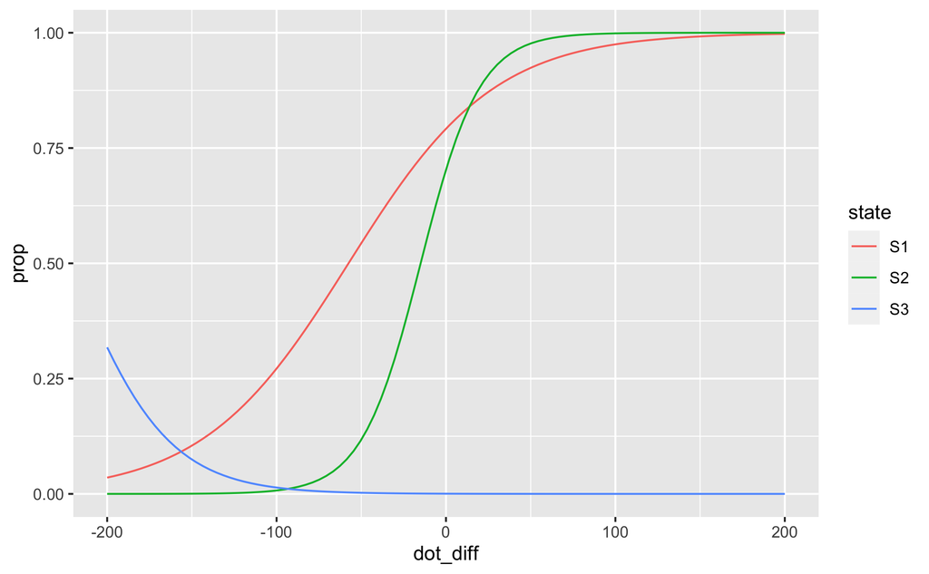

```r
psycho_3_s01 |> ggplot(aes(x = dot_diff, y = prop, color = state)) +
  geom_line()
```

Predominancia:

```r
posterior_wins3_s01 <- glm_hmm3_s01$posterior_probs |>
    group_by(trial) %>%
    filter(p == max(p)) %>%
    select(-p)

posterior_wins3_s01
```

| session | trial | state |
| --- | --- | --- |
| 1 | 1 | S3 |
| 1 | 2 | S3 |
| 1 | 3 | S1 |
| 1 | 4 | S1 |
| 1 | 5 | S1 |
| 1 | 6 | S1 |
| 1 | 7 | S1 |
| 1 | 8 | S1 |
| 1 | 9 | S1 |
| 1 | 10 | S1 |

[output cut: 200 more lines]

```r
posterior_wins3_s01 |>
  ungroup() |>
  count(state)
```

| state | n |
| --- | --- |
| S1 | 156 |
| S2 | 51 |
| S3 | 3 |

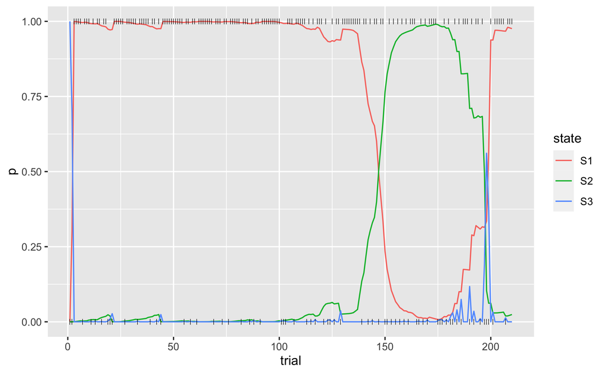

```r
s01_trials <- data_trials %>%
  filter(subject == 1) %>%
  mutate(session = 1,
         intercept = 1,
         dot_diff = dot_diff) %>%
  ungroup() %>%
  select(session, response, intercept, dot_diff, trial)

s01_3_trials_plot <- ggplot() +
  geom_line(data = glm_hmm3_s01$posterior_probs,
            aes(x = trial, y = p, color = state)) +
  geom_point(data = s01_trials, aes(x = trial, y = response), shape = "|")

s01_3_trials_plot
```

Tres estados con diversas condiciones iniciales

```r
glm_hmm3_seeds_s01 <- s01_design_matrix %>%
  glm_hmm_r(.num_states = 3, .seeds = 1:20, .all_seeds = TRUE)

glm_hmm3_seeds_s01
```

| seed | log_lik | n_par | fit |
| --- | --- | --- | --- |
| 1 | -104.7783 | 12 |  |
| 2 | -104.7793 | 12 |  |
| 3 | -104.7782 | 12 |  |
| 4 | -104.3414 | 12 |  |
| 5 | -104.7795 | 12 |  |
| 6 | -104.7794 | 12 |  |
| 7 | -104.7796 | 12 |  |
| 8 | -104.5653 | 12 |  |
| 9 | -104.7783 | 12 |  |
| 10 | -104.7785 | 12 |  |

[output cut: 10 more lines]

No sé si esto sea normal

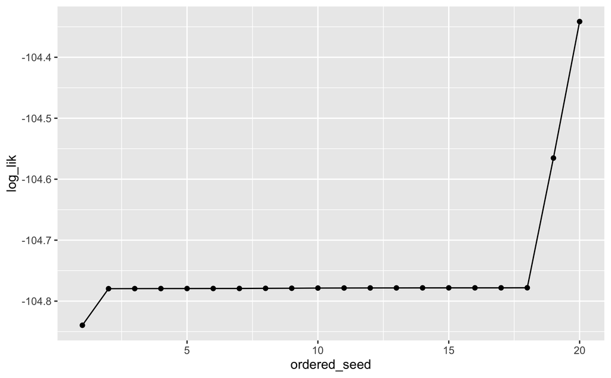

```r
glm_hmm3_seeds_s01 %>%
  arrange(log_lik) %>%
  mutate(ordered_seed = row_number()) %>%
  ggplot(aes(ordered_seed, log_lik)) +
  geom_line() +
  geom_point()
```

```r
glm_hmm3_s01_best <- glm_hmm3_seeds_s01 |>
   filter(log_lik == max(log_lik)) |>
   pluck("fit") %>%
   pluck(1)

glm_hmm3_s01_best
```

| session | response | intercept | dot_diff |
| --- | --- | --- | --- |
| 1 | 0 | 1 | 43 |
| 1 | 0 | 1 | 15 |
| 1 | 1 | 1 | 13 |
| 1 | 1 | 1 | 2 |
| 1 | 1 | 1 | 49 |
| 1 | 1 | 1 | 52 |
| 1 | 0 | 1 | -33 |
| 1 | 1 | 1 | -4 |
| 1 | 1 | 1 | -58 |
| 1 | 1 | 1 | 21 |

[output cut: 200 more lines]

```
$log_prob
[1] -151.3022

$log_prior
[1] -46.9608

$log_lik
[1] -104.3414

$n_par
[1] 12

$recovered_weights
```

| state | coef | value |
| --- | --- | --- |
| S1 | V1 | 1.25658147 |
| S1 | V2 | 0.02259920 |
| S2 | V1 | 35.51343604 |
| S2 | V2 | -2.56637074 |
| S3 | V1 | 0.75575867 |
| S3 | V2 | 0.06796824 |

```
$transitions_tengo_que_reordenar_segun_estados_ordenados
            [,1]        [,2]         [,3]
[1,] -0.00824594 -21.8755528  -4.80215453
[2,] -0.94578333  -0.4916363 -74.28852472
[3,] -3.40139768 -11.0542293  -0.03391101

$posterior_probs
```

| session | trial | state | p |
| --- | --- | --- | --- |
| 1 | 1 | S1 | 2.976955e-10 |
| 1 | 1 | S2 | 1.000000e+00 |
| 1 | 1 | S3 | 2.222163e-11 |
| 1 | 2 | S1 | 1.161595e-01 |
| 1 | 2 | S2 | 8.838405e-01 |
| 1 | 2 | S3 | 2.043480e-11 |
| 1 | 3 | S1 | 5.192608e-01 |
| 1 | 3 | S2 | 4.804546e-01 |
| 1 | 3 | S3 | 2.846204e-04 |
| 1 | 4 | S1 | 7.876594e-01 |

[output cut: 620 more lines]

```
NA
```

```r
psycho_3_s01_best <- glm_hmm3_s01_best$recovered_weights |>
  group_by(state) |>
  reframe(create_psychometric(dot_diff, value))
```

DL: AÑADIR PUNTOS

Esto también lo veo muy extraño

Modelo por proporciones:

```r
averages_states3_S01 <- glm_hmm3_s01_best$model_matrix_with_session %>%
    mutate(trial = row_number()) %>%
    left_join(posterior_wins3_s01, by = c("session", "trial")) %>%
    mutate(dot_diff_bin = cut_interval(dot_diff, 10)) |>
    group_by(dot_diff_bin, state) %>%
    summarise(dot_diff = mean(dot_diff), prob = mean(response), n = n(), .groups = "keep")
```

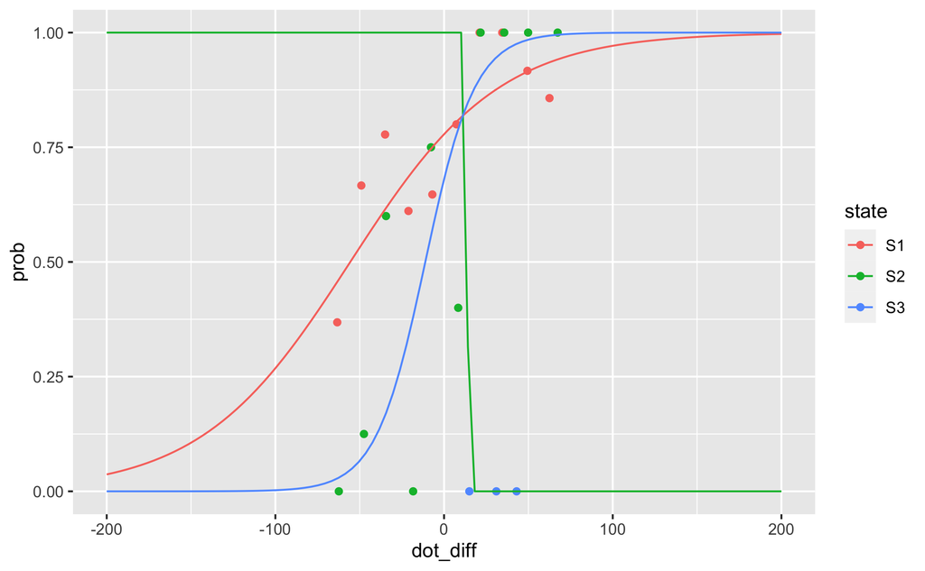

```r
averages_states3_S01 |>
  ggplot(aes(dot_diff, prob, color = state)) +
  geom_point() +
  geom_line(data = psycho_3_s01_best,
            aes(x = dot_diff, y = prop))
```

```r
averages_states3_S01 |>
  filter(state == "S2")
```

| dot_diff_bin | state | dot_diff | prob | n |
| --- | --- | --- | --- | --- |
| [-70,-56] | S2 | -62.37500 | 0.000 | 8 |
| (-56,-42] | S2 | -47.50000 | 0.125 | 8 |
| (-42,-28] | S2 | -34.40000 | 0.600 | 5 |
| (-28,-14] | S2 | -18.33333 | 0.000 | 3 |
| (-14,0] | S2 | -7.75000 | 0.750 | 4 |
| (0,14] | S2 | 8.40000 | 0.400 | 5 |
| (14,28] | S2 | 21.66667 | 1.000 | 6 |
| (28,42] | S2 | 35.66667 | 1.000 | 3 |
| (42,56] | S2 | 49.83333 | 1.000 | 6 |
| (56,70] | S2 | 67.33333 | 1.000 | 3 |

| All 3 S |
| --- |

```r
glm_hmm3_all_seeds <- design_matrix_all |>
  group_by(subject) |>
  nest() %>%
  rowwise() %>%
  mutate(fit = list(glm_hmm_r(data,
                              .num_states = 3)))#, .seeds = 1:20,
                              #.all_seeds = TRUE)))
```

```r
glm_hmm3_all <- glm_hmm3_all_seeds #%>%
  #mutate(fit = list(glm_hmm_extract_best(fit)))
```

```r
glm_hmm3_all |>
      select(-data) |>
      unnest_wider(fit) |>
      select(subject, recovered_weights) |>
      unnest(recovered_weights)
```

| subject | state | coef | value |
| --- | --- | --- | --- |
| 1 | S1 | V1 | 1.335479e+00 |
| 1 | S1 | V2 | 2.321393e-02 |
| 1 | S2 | V1 | 8.598963e-01 |
| 1 | S2 | V2 | 5.752535e-02 |
| 1 | S3 | V1 | -7.775090e+00 |
| 1 | S3 | V2 | -3.505633e-02 |
| 2 | S1 | V1 | 1.020944e+00 |
| 2 | S1 | V2 | 4.441806e-02 |
| 2 | S2 | V1 | 7.134895e-01 |
| 2 | S2 | V2 | 3.870150e-02 |

[output cut: 290 more lines]

```r
liks_glm_hmm3_all <- glm_hmm3_all %>%
  unnest_wider(fit) %>%
  mutate(n = map(data, count)) %>%
  unnest(n) %>%
  select(subject, log_lik, n_par, n) %>%
  mutate(model = "int-slo 3")
```

plotting

```r
plots_3_all <- glm_hmm3_all %>%
    rowwise() %>%
    mutate(p = list(plotting_one_participant(fit, subject)))

plots_3_all_grid <- plot_grid(plotlist = plots_3_all$p, ncol =3)

file_name <- paste0("figures/", deparse(substitute(.glm_hmm)), ".pdf")

ggsave("figures/plots_3_grid.pdf" ,
       plots_3_all_grid, width = 40, height = 40)
```